# (Bike Sharing Analysis with Ford GoBike Data- March 2020 version)

## by (Adel Abu Hashim)

> may 2020

## Intro

> The project is about bicycle-sharing systems; many people particulary in Euorpe can't live without this amazing idean besides it is so good for investors. Using Bikes reduces pollution due to minimize using gas vicyles; so it is benificial for ordinary people(good for time and price), investors and also our environment.

## Preliminary Wrangling

> You will see analsyis due to last version of data second half of 2017

```python
# import all packages and set plots to be embedded inline
import numpy as np
import pandas as pd
import matplotlib.pyplot as plt
import seaborn as sb

%matplotlib inline
```

## Univariate Exploration

> In this section, I'll start by looking at user types.

### Which user type uses bikes most?

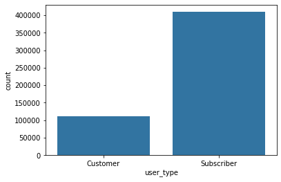

```python
base_color = sb.color_palette()[0]
sb.countplot(data = ford, x = 'user_type', color = base_color)
```

**We could see that subscribers use bikes more than customers** this may due to cupons or other services provided for subscribers!

### Which bike rented the most?

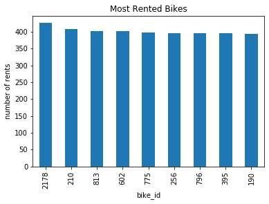

```python
#get bikes' ids for most rented bikes
ford['bike_id'].value_counts()[1:10].plot(kind='bar')
plt.title('Most Rented Bikes')
plt.ylabel ('number of rents')
plt.xlabel ('bike_id')
```

##### Are bikes with those ids are from specific type, form specific factory!

## In which month bikes rented more?

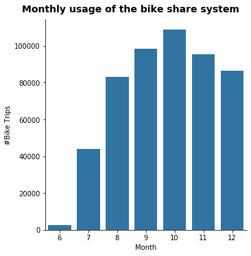

```python
# monthly usege of the bike sharing system
plot = sb.catplot(data=ford_clean, x='start_time_month', kind='count', color = base_color)
plot.set_axis_labels("Month", "#Bike Trips")
plot.fig.suptitle('Monthly usage of the bike share system', y=1.03, fontsize=14, fontweight='semibold');
```

## Average time of trip?

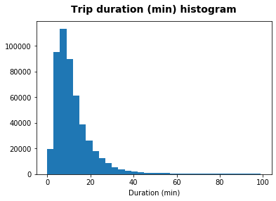

```python
ford_clean['duration_min'] = ford_clean['duration_sec'] / 60
plt.hist(data = ford_clean, x = 'duration_min', bins = np.arange(0, 100,3))
plt.title("Trip duration (min) histogram", y=1.03, fontsize=14, fontweight='semibold')
plt.xlabel('Duration (min)')
```

### Discuss the distribution(s) of your variable(s) of interest. Were there any unusual points? Did you need to perform any transformations?

> user types as expected; found that subscribers use the serviice more than customers and this was and expection as subscribers have copuns and sales.

### Of the features you investigated, were there any unusual distributions? Did you perform any operations on the data to tidy, adjust, or change the form of the data? If so, why did you do this?

> The Monthly usage of the bike share system, people in june and july use the service less than winter months which is strange as in winter it is hard to use bike due to raining and snow.

## Bivariate Exploration

> In this section, investigate relationships between pairs of variables in your data. Make sure the variables that you cover here have been introduced in some fashion in the previous section (univariate exploration).

## Does month impact the trip duration?

```python
ford_clean['start_time_month'].value_counts()
```

```
10    108937
9      98558
11     95612
12     86539
8      83292
7      44073
6       2689
Name: start_time_month, dtype: int64
```

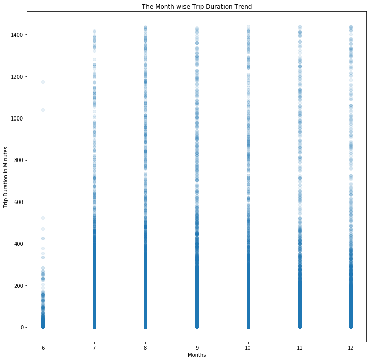

```python
plt.figure(figsize = [12,12])
plt.scatter(data = ford_clean , x = 'start_time_month' , y = 'duration_min' , alpha = 0.1 )
plt.title('The Month-wise Trip Duration Trend')
plt.xlabel('Months')
plt.ylabel('Trip Duration in Minutes')
```

##### We can deduce that hotter months are less to use service

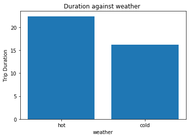

```python
# We categorize our months for two categories; hot and cold
hot = ford_clean.query('start_time_month in ["6" , "7" , "8"]' ).duration_min.mean ()
cold = ford_clean.query('start_time_month in ["10" , "11" , "12"] ').duration_min.mean()

plt.bar(['hot','cold'],[hot , cold] )
plt.title('Duration against weather ')
plt.xlabel('weather')
plt.ylabel('Trip Duration');
```

### Talk about some of the relationships you observed in this part of the investigation. How did the feature(s) of interest vary with other features in the dataset?

```
Thus, we may conclude that the weather does affect the trip duration. Also, unlike cities like Boston,We can deduce that difference not great large as many american cities have cold in months we set to be hot!
```

### Did you observe any interesting relationships between the other features (not the main feature(s) of interest)?

> yes, weather affects the duration of trip!

## Multivariate Exploration

> Create plots of three or more variables to investigate your data even further. Make sure that your investigations are justified, and follow from your work in the previous sections.

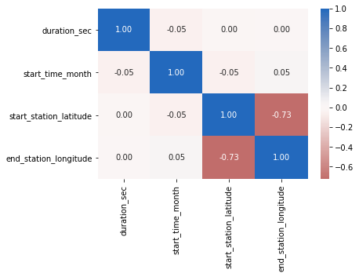

```python
sb.heatmap(correlation.corr(), annot = True, fmt = '.2f', cmap = 'vlag_r', center = 0)
```

## What is the effect of user typr on trip duaration ?

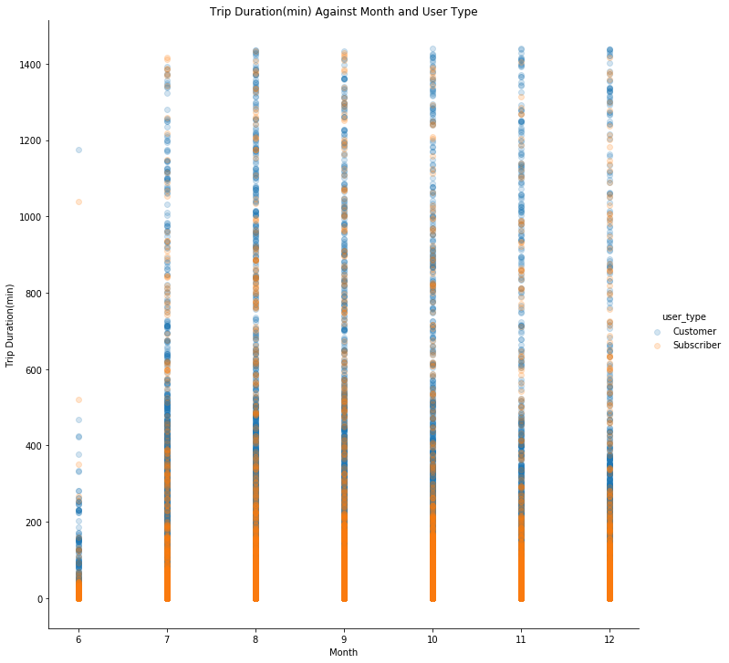

```python
import seaborn as sb
import matplotlib.pyplot as plt

g = sb.FacetGrid(data = ford_clean, hue = 'user_type', height = 10)
g.map(plt.scatter, 'start_time_month','duration_min', alpha = 0.2)
g.add_legend()
plt.title('Trip Duration(min) Against Month and User Type')
plt.xlabel('Month')
plt.ylabel('Trip Duration(min)');
```

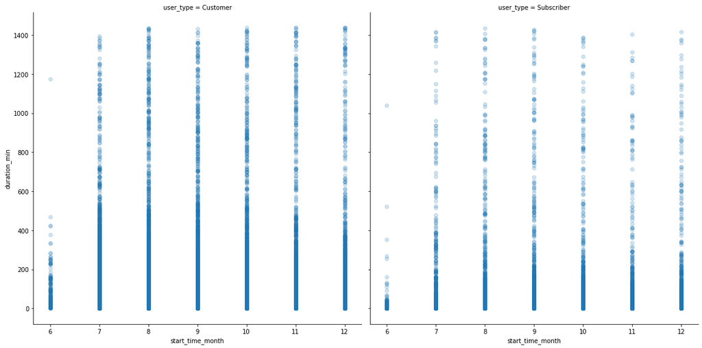

```python
m = sb.FacetGrid(data =  ford_clean, col = 'user_type', size = 8, col_wrap = 2)
m.map(sb.regplot, 'start_time_month', 'duration_min', y_jitter = 0.04, fit_reg = False,scatter_kws = {'alpha' : 1/5});
```